# Lending Club - Loan Default Modeling

Back to Portfolio Archive

Lending Club Loan Prediction

A Bank Loan Default Prediction with Machine Learning Classification Model

*Posted by Yun (Jessica) Yan on March 8, 2020*

# Lending Club - Loan Default Modeling

## 0. Setup

```python
import numpy as np
import pandas as pd
import matplotlib.pyplot as plt
import seaborn as sns
import matplotlib.patches as patches
from sklearn.metrics import roc_curve,auc
from scipy import interp
```

```python
pd.set_option('display.max_columns', 500)
```

```python
loan = pd.read_csv("E:/Downloads/CreditNinja_ModelingChallenge/data.csv")
print(loan.shape)
loan.head()
```

```
(80000, 26)
```

|  | id | loan_amnt | term | installment | emp_length | home_ownership | annual_inc | verification_status | issue_d | loan_status | purpose | addr_state | dti | earliest_cr_line | fico_range_low | fico_range_high | last_credit_pull_d | last_fico_range_high | last_fico_range_low | acc_now_delinq | delinq_amnt | delinq_2yrs | mths_since_last_delinq | mths_since_last_record | inq_last_6mths | inq_last_12m |
| --- | --- | --- | --- | --- | --- | --- | --- | --- | --- | --- | --- | --- | --- | --- | --- | --- | --- | --- | --- | --- | --- | --- | --- | --- | --- | --- |
| 0 | 88787390 | 30000 | 60 months | 761.64 | 6 years | RENT | 100100.0 | Verified | Sep-2016 | Current | debt_consolidation | SC | 27.42 | Jan-1976 | 690 | 694 | Dec-2016 | 709 | 705 | 0 | 0 | 0 | 26.0 | NaN | 0 | 0.0 |
| 1 | 74722660 | 30000 | 60 months | 692.93 | 10+ years | MORTGAGE | 235000.0 | Source Verified | Apr-2016 | Current | home_improvement | PA | 7.50 | Jan-1995 | 670 | 674 | Dec-2016 | 649 | 645 | 0 | 0 | 1 | 16.0 | NaN | 1 | 3.0 |
| 2 | 67919555 | 16000 | 60 months | 379.39 | 6 years | RENT | 84000.0 | Not Verified | Jan-2016 | Current | debt_consolidation | FL | 27.87 | Aug-1998 | 735 | 739 | Dec-2016 | 739 | 735 | 0 | 0 | 0 | 80.0 | NaN | 0 | 2.0 |
| 3 | 54027458 | 14000 | 36 months | 439.88 | 5 years | RENT | 50000.0 | Source Verified | Jul-2015 | Fully Paid | debt_consolidation | WV | 21.65 | Oct-1996 | 725 | 729 | Oct-2016 | 749 | 745 | 0 | 0 | 0 | NaN | 42.0 | 0 | NaN |
| 4 | 72594974 | 7500 | 36 months | 252.67 | 3 years | MORTGAGE | 68000.0 | Not Verified | Feb-2016 | Fully Paid | debt_consolidation | OH | 29.09 | Nov-2000 | 660 | 664 | Dec-2016 | 709 | 705 | 0 | 0 | 0 | NaN | NaN | 2 | 5.0 |

## 1. Data Review and Dependent Variable Definition

I chose **loan_status** as the dependent variable and turned it into a **binary classification** problem by setting 'Default' as '1' and other status as '0'. Since we only want to focus on the default clients, there is no need to identify the difference between 'Current' and 'Fully Paid'.

```python
# create new dependent variable: default
loan.loc[loan['loan_status'] == 'Default', 'Default'] = 1
loan.loc[loan['loan_status'] != 'Default', 'Default'] = 0

# drop the original unique id and loan_status column
loan = loan.drop(['id', 'loan_status'], axis=1)
print(loan.shape)
loan.head()
```

```
(80000, 25)
```

|  | loan_amnt | term | installment | emp_length | home_ownership | annual_inc | verification_status | issue_d | purpose | addr_state | dti | earliest_cr_line | fico_range_low | fico_range_high | last_credit_pull_d | last_fico_range_high | last_fico_range_low | acc_now_delinq | delinq_amnt | delinq_2yrs | mths_since_last_delinq | mths_since_last_record | inq_last_6mths | inq_last_12m | Default |
| --- | --- | --- | --- | --- | --- | --- | --- | --- | --- | --- | --- | --- | --- | --- | --- | --- | --- | --- | --- | --- | --- | --- | --- | --- | --- |
| 0 | 30000 | 60 months | 761.64 | 6 years | RENT | 100100.0 | Verified | Sep-2016 | debt_consolidation | SC | 27.42 | Jan-1976 | 690 | 694 | Dec-2016 | 709 | 705 | 0 | 0 | 0 | 26.0 | NaN | 0 | 0.0 | 0.0 |
| 1 | 30000 | 60 months | 692.93 | 10+ years | MORTGAGE | 235000.0 | Source Verified | Apr-2016 | home_improvement | PA | 7.50 | Jan-1995 | 670 | 674 | Dec-2016 | 649 | 645 | 0 | 0 | 1 | 16.0 | NaN | 1 | 3.0 | 0.0 |
| 2 | 16000 | 60 months | 379.39 | 6 years | RENT | 84000.0 | Not Verified | Jan-2016 | debt_consolidation | FL | 27.87 | Aug-1998 | 735 | 739 | Dec-2016 | 739 | 735 | 0 | 0 | 0 | 80.0 | NaN | 0 | 2.0 | 0.0 |
| 3 | 14000 | 36 months | 439.88 | 5 years | RENT | 50000.0 | Source Verified | Jul-2015 | debt_consolidation | WV | 21.65 | Oct-1996 | 725 | 729 | Oct-2016 | 749 | 745 | 0 | 0 | 0 | NaN | 42.0 | 0 | NaN | 0.0 |
| 4 | 7500 | 36 months | 252.67 | 3 years | MORTGAGE | 68000.0 | Not Verified | Feb-2016 | debt_consolidation | OH | 29.09 | Nov-2000 | 660 | 664 | Dec-2016 | 709 | 705 | 0 | 0 | 0 | NaN | NaN | 2 | 5.0 | 0.0 |

## 2. Data Cleansing

My data cleaning methodology and findings are listed as below.

1. First, I looked at all the variables. I found that there are some variables containing information that happens after the loan underwriting. Since it may raise data leakage issues, I chose to drop them. In addition, some variables are not relevant to one's ability to pay the loan, such as the state information. I dropped there variables as well.
- Second, I found that there are four columns in total with missing values. As for those with more than 40% NAs, I chose to drop them. Also, for the emp_length column with only a few NAs, I chose to drop the rows with missing value in this column.
- Third, there are a few outliers (9999) in the `dit` column. However, they have already been dropped in the second step.
- Fourth, I dealt with the nominal and ordinal variables in the dataset. emp_length is the only ordinal variable. I assigned different numbers to different levels accordingly to convert it into a numerical variable that can be fed into the model. As for the four nominal variables, I used the get_dummies() function to conduct one-hot encoding.
- Fifth, since there are some variables containing really large values, such as `annual_inc` and `dit`, I decided to normalize the data to ensure the model performance.

### 2.1 Select appropriate variables

First, there are several variables we would like to drop.

- **last_credit_pull_d**: This information happens after the loan decision and has no predictive power for our model.
- **last_fico_range_high**: This information happens after the loan decision and has no predictive power for our model.
- **last_fico_range_low**: This information happens after the loan decision and has no predictive power for our model.
- **issue_d**: This information happens after the loan decision and has no predictive power for our model.
- **addr_state**: The state of the borrower can not reflect one's ability to pay the loan.
- **earliest_cr_line**: The borrower's earliest reported credit line open month is not relevant one's ability to pay the loan.

```python
loan = loan.drop(['last_credit_pull_d','last_fico_range_high','last_fico_range_low','addr_state','issue_d','earliest_cr_line'], axis=1)
print(loan.shape)
loan.head()
```

```
(80000, 19)
```

|  | loan_amnt | term | installment | emp_length | home_ownership | annual_inc | verification_status | purpose | dti | fico_range_low | fico_range_high | acc_now_delinq | delinq_amnt | delinq_2yrs | mths_since_last_delinq | mths_since_last_record | inq_last_6mths | inq_last_12m | Default |
| --- | --- | --- | --- | --- | --- | --- | --- | --- | --- | --- | --- | --- | --- | --- | --- | --- | --- | --- | --- |
| 0 | 30000 | 60 months | 761.64 | 6 years | RENT | 100100.0 | Verified | debt_consolidation | 27.42 | 690 | 694 | 0 | 0 | 0 | 26.0 | NaN | 0 | 0.0 | 0.0 |
| 1 | 30000 | 60 months | 692.93 | 10+ years | MORTGAGE | 235000.0 | Source Verified | home_improvement | 7.50 | 670 | 674 | 0 | 0 | 1 | 16.0 | NaN | 1 | 3.0 | 0.0 |
| 2 | 16000 | 60 months | 379.39 | 6 years | RENT | 84000.0 | Not Verified | debt_consolidation | 27.87 | 735 | 739 | 0 | 0 | 0 | 80.0 | NaN | 0 | 2.0 | 0.0 |
| 3 | 14000 | 36 months | 439.88 | 5 years | RENT | 50000.0 | Source Verified | debt_consolidation | 21.65 | 725 | 729 | 0 | 0 | 0 | NaN | 42.0 | 0 | NaN | 0.0 |
| 4 | 7500 | 36 months | 252.67 | 3 years | MORTGAGE | 68000.0 | Not Verified | debt_consolidation | 29.09 | 660 | 664 | 0 | 0 | 0 | NaN | NaN | 2 | 5.0 | 0.0 |

### 2.2 Dealing with NAs

```python
# check the NAs in each column
isnull = loan.isnull().sum().sort_values(ascending=False)/len(loan)
print('col_count:',isnull.count())
isnull
```

```
col_count: 19
```

```
mths_since_last_record    0.818350
inq_last_12m              0.532563
mths_since_last_delinq    0.477675
emp_length                0.060862
Default                   0.000000
purpose                   0.000000
term                      0.000000
installment               0.000000
home_ownership            0.000000
annual_inc                0.000000
verification_status       0.000000
fico_range_low            0.000000
dti                       0.000000
fico_range_high           0.000000
acc_now_delinq            0.000000
delinq_amnt               0.000000
delinq_2yrs               0.000000
inq_last_6mths            0.000000
loan_amnt                 0.000000
dtype: float64
```

```python
# drop the columns with over 40% missing values
loan = loan.dropna(thresh=len(loan)*0.6, axis=1)

print(loan.shape)
loan.head()
```

```
(80000, 16)
```

|  | loan_amnt | term | installment | emp_length | home_ownership | annual_inc | verification_status | purpose | dti | fico_range_low | fico_range_high | acc_now_delinq | delinq_amnt | delinq_2yrs | inq_last_6mths | Default |
| --- | --- | --- | --- | --- | --- | --- | --- | --- | --- | --- | --- | --- | --- | --- | --- | --- |
| 0 | 30000 | 60 months | 761.64 | 6 years | RENT | 100100.0 | Verified | debt_consolidation | 27.42 | 690 | 694 | 0 | 0 | 0 | 0 | 0.0 |
| 1 | 30000 | 60 months | 692.93 | 10+ years | MORTGAGE | 235000.0 | Source Verified | home_improvement | 7.50 | 670 | 674 | 0 | 0 | 1 | 1 | 0.0 |
| 2 | 16000 | 60 months | 379.39 | 6 years | RENT | 84000.0 | Not Verified | debt_consolidation | 27.87 | 735 | 739 | 0 | 0 | 0 | 0 | 0.0 |
| 3 | 14000 | 36 months | 439.88 | 5 years | RENT | 50000.0 | Source Verified | debt_consolidation | 21.65 | 725 | 729 | 0 | 0 | 0 | 0 | 0.0 |
| 4 | 7500 | 36 months | 252.67 | 3 years | MORTGAGE | 68000.0 | Not Verified | debt_consolidation | 29.09 | 660 | 664 | 0 | 0 | 0 | 2 | 0.0 |

```python
loan.select_dtypes(include=[np.number]).describe().T
```

|  | count | mean | std | min | 25% | 50% | 75% | max |
| --- | --- | --- | --- | --- | --- | --- | --- | --- |
| loan_amnt | 80000.0 | 15055.793750 | 8729.299624 | 1000.00 | 8000.00 | 13275.00 | 20000.00 | 40000.00 |
| installment | 80000.0 | 443.595158 | 255.693326 | 30.12 | 258.10 | 382.50 | 585.08 | 1536.95 |
| annual_inc | 80000.0 | 77789.952824 | 86486.732410 | 0.00 | 47000.00 | 65000.00 | 92500.00 | 8706582.00 |
| dti | 80000.0 | 19.446568 | 61.871127 | 0.00 | 12.43 | 18.44 | 25.17 | 9999.00 |
| fico_range_low | 80000.0 | 694.314000 | 30.744603 | 660.00 | 670.00 | 685.00 | 710.00 | 845.00 |
| fico_range_high | 80000.0 | 698.314112 | 30.745156 | 664.00 | 674.00 | 689.00 | 714.00 | 850.00 |
| acc_now_delinq | 80000.0 | 0.006488 | 0.084235 | 0.00 | 0.00 | 0.00 | 0.00 | 3.00 |
| delinq_amnt | 80000.0 | 16.692025 | 848.289643 | 0.00 | 0.00 | 0.00 | 0.00 | 110626.00 |
| delinq_2yrs | 80000.0 | 0.352275 | 0.942411 | 0.00 | 0.00 | 0.00 | 0.00 | 39.00 |
| inq_last_6mths | 80000.0 | 0.565950 | 0.863342 | 0.00 | 0.00 | 0.00 | 1.00 | 6.00 |
| Default | 80000.0 | 0.075463 | 0.264138 | 0.00 | 0.00 | 0.00 | 0.00 | 1.00 |

```python
loan.select_dtypes(include=['object']).describe().T
```

|  | count | unique | top | freq |
| --- | --- | --- | --- | --- |
| term | 80000 | 2 | 36 months | 56346 |
| emp_length | 75131 | 11 | 10+ years | 26972 |
| home_ownership | 80000 | 4 | MORTGAGE | 39054 |
| verification_status | 80000 | 3 | Source Verified | 33189 |
| purpose | 80000 | 13 | debt_consolidation | 46721 |

```python
# drop the rows with missing values in the `emp_length` variable
loan = loan.dropna(axis=0)
print(loan.shape)
loan.head()
```

```
(75131, 16)
```

|  | loan_amnt | term | installment | emp_length | home_ownership | annual_inc | verification_status | purpose | dti | fico_range_low | fico_range_high | acc_now_delinq | delinq_amnt | delinq_2yrs | inq_last_6mths | Default |
| --- | --- | --- | --- | --- | --- | --- | --- | --- | --- | --- | --- | --- | --- | --- | --- | --- |
| 0 | 30000 | 60 months | 761.64 | 6 years | RENT | 100100.0 | Verified | debt_consolidation | 27.42 | 690 | 694 | 0 | 0 | 0 | 0 | 0.0 |
| 1 | 30000 | 60 months | 692.93 | 10+ years | MORTGAGE | 235000.0 | Source Verified | home_improvement | 7.50 | 670 | 674 | 0 | 0 | 1 | 1 | 0.0 |
| 2 | 16000 | 60 months | 379.39 | 6 years | RENT | 84000.0 | Not Verified | debt_consolidation | 27.87 | 735 | 739 | 0 | 0 | 0 | 0 | 0.0 |
| 3 | 14000 | 36 months | 439.88 | 5 years | RENT | 50000.0 | Source Verified | debt_consolidation | 21.65 | 725 | 729 | 0 | 0 | 0 | 0 | 0.0 |
| 4 | 7500 | 36 months | 252.67 | 3 years | MORTGAGE | 68000.0 | Not Verified | debt_consolidation | 29.09 | 660 | 664 | 0 | 0 | 0 | 2 | 0.0 |

### 2.3 Dealing with Ordinal / Nominal variables

The **emp_length** variable is an ordinal variable. Therefore, I assigned different numbers to different levels accordingly to convert it into a numerical variable that can feed the model.

```python
map = {
    "emp_length": {
        "10+ years": 10,
        "9 years": 9,
        "8 years": 8,
        "7 years": 7,
        "6 years": 6,
        "5 years": 5,
        "4 years": 4,
        "3 years": 3,
        "2 years": 2,
        "1 year": 1,
        "< 1 year": 0
    }
}

loan = loan.replace(map)
print(loan.shape)
loan.head()
```

```
(75131, 16)
```

|  | loan_amnt | term | installment | emp_length | home_ownership | annual_inc | verification_status | purpose | dti | fico_range_low | fico_range_high | acc_now_delinq | delinq_amnt | delinq_2yrs | inq_last_6mths | Default |
| --- | --- | --- | --- | --- | --- | --- | --- | --- | --- | --- | --- | --- | --- | --- | --- | --- |
| 0 | 30000 | 60 months | 761.64 | 6 | RENT | 100100.0 | Verified | debt_consolidation | 27.42 | 690 | 694 | 0 | 0 | 0 | 0 | 0.0 |
| 1 | 30000 | 60 months | 692.93 | 10 | MORTGAGE | 235000.0 | Source Verified | home_improvement | 7.50 | 670 | 674 | 0 | 0 | 1 | 1 | 0.0 |
| 2 | 16000 | 60 months | 379.39 | 6 | RENT | 84000.0 | Not Verified | debt_consolidation | 27.87 | 735 | 739 | 0 | 0 | 0 | 0 | 0.0 |
| 3 | 14000 | 36 months | 439.88 | 5 | RENT | 50000.0 | Source Verified | debt_consolidation | 21.65 | 725 | 729 | 0 | 0 | 0 | 0 | 0.0 |
| 4 | 7500 | 36 months | 252.67 | 3 | MORTGAGE | 68000.0 | Not Verified | debt_consolidation | 29.09 | 660 | 664 | 0 | 0 | 0 | 2 | 0.0 |

As for the four nominal variables, I used the `get_dummies()` function to conduct one-hot encoding.

```python
n_columns = ["term","home_ownership", "verification_status", "purpose"]
dummy_df = pd.get_dummies(loan[n_columns],drop_first=True)
loan = pd.concat([loan, dummy_df], axis=1)
loan = loan.drop(n_columns, axis=1)
print(loan.shape)
loan.head()
```

```
(75131, 30)
```

|  | loan_amnt | installment | emp_length | annual_inc | dti | fico_range_low | fico_range_high | acc_now_delinq | delinq_amnt | delinq_2yrs | inq_last_6mths | Default | term_60 months | home_ownership_MORTGAGE | home_ownership_OWN | home_ownership_RENT | verification_status_Source Verified | verification_status_Verified | purpose_credit_card | purpose_debt_consolidation | purpose_home_improvement | purpose_house | purpose_major_purchase | purpose_medical | purpose_moving | purpose_other | purpose_renewable_energy | purpose_small_business | purpose_vacation | … |
| --- | --- | --- | --- | --- | --- | --- | --- | --- | --- | --- | --- | --- | --- | --- | --- | --- | --- | --- | --- | --- | --- | --- | --- | --- | --- | --- | --- | --- | --- | --- |
| 0 | 30000 | 761.64 | 6 | 100100.0 | 27.42 | 690 | 694 | 0 | 0 | 0 | 0 | 0.0 | 1 | 0 | 0 | 1 | 0 | 1 | 0 | 1 | 0 | 0 | 0 | 0 | 0 | 0 | 0 | 0 | 0 | … |
| 1 | 30000 | 692.93 | 10 | 235000.0 | 7.50 | 670 | 674 | 0 | 0 | 1 | 1 | 0.0 | 1 | 1 | 0 | 0 | 1 | 0 | 0 | 0 | 1 | 0 | 0 | 0 | 0 | 0 | 0 | 0 | 0 | … |
| 2 | 16000 | 379.39 | 6 | 84000.0 | 27.87 | 735 | 739 | 0 | 0 | 0 | 0 | 0.0 | 1 | 0 | 0 | 1 | 0 | 0 | 0 | 1 | 0 | 0 | 0 | 0 | 0 | 0 | 0 | 0 | 0 | … |
| 3 | 14000 | 439.88 | 5 | 50000.0 | 21.65 | 725 | 729 | 0 | 0 | 0 | 0 | 0.0 | 0 | 0 | 0 | 1 | 1 | 0 | 0 | 1 | 0 | 0 | 0 | 0 | 0 | 0 | 0 | 0 | 0 | … |
| 4 | 7500 | 252.67 | 3 | 68000.0 | 29.09 | 660 | 664 | 0 | 0 | 0 | 2 | 0.0 | 0 | 1 | 0 | 0 | 0 | 0 | 0 | 1 | 0 | 0 | 0 | 0 | 0 | 0 | 0 | 0 | 0 | … |

### 2.4 Normalize the Data

```python
columns = loan.columns
features = columns.drop('Default')
features_s = columns.drop('Default').drop(dummy_df.columns)

from sklearn.preprocessing import StandardScaler
sc =StandardScaler()
loan[features_s] =sc.fit_transform(loan[features_s])
print(loan.shape)
loan.head()
```

```
(75131, 30)
```

|  | loan_amnt | installment | emp_length | annual_inc | dti | fico_range_low | fico_range_high | acc_now_delinq | delinq_amnt | delinq_2yrs | inq_last_6mths | Default | term_60 months | home_ownership_MORTGAGE | home_ownership_OWN | home_ownership_RENT | verification_status_Source Verified | verification_status_Verified | purpose_credit_card | purpose_debt_consolidation | purpose_home_improvement | purpose_house | purpose_major_purchase | purpose_medical | purpose_moving | purpose_other | purpose_renewable_energy | purpose_small_business | purpose_vacation | … |
| --- | --- | --- | --- | --- | --- | --- | --- | --- | --- | --- | --- | --- | --- | --- | --- | --- | --- | --- | --- | --- | --- | --- | --- | --- | --- | --- | --- | --- | --- | --- |
| 0 | 1.685021 | 1.220027 | -0.004434 | 0.231708 | 0.945250 | -0.139242 | -0.139244 | -0.078531 | -0.019703 | -0.376920 | -0.655131 | 0.0 | 1 | 0 | 0 | 1 | 0 | 1 | 0 | 1 | 0 | 0 | 0 | 0 | 0 | 0 | 0 | 0 | 0 | … |
| 1 | 1.685021 | 0.952119 | 1.072726 | 1.753647 | -1.275759 | -0.793480 | -0.793469 | -0.078531 | -0.019703 | 0.675221 | 0.503220 | 0.0 | 1 | 1 | 0 | 0 | 1 | 0 | 0 | 0 | 1 | 0 | 0 | 0 | 0 | 0 | 0 | 0 | 0 | … |
| 2 | 0.084683 | -0.270408 | -0.004434 | 0.050069 | 0.995424 | 1.332793 | 1.332763 | -0.078531 | -0.019703 | -0.376920 | -0.655131 | 0.0 | 1 | 0 | 0 | 1 | 0 | 0 | 0 | 1 | 0 | 0 | 0 | 0 | 0 | 0 | 0 | 0 | 0 | … |
| 3 | -0.143937 | -0.034550 | -0.273724 | -0.333519 | 0.301916 | 1.005674 | 1.005650 | -0.078531 | -0.019703 | -0.376920 | -0.655131 | 0.0 | 0 | 0 | 0 | 1 | 1 | 0 | 0 | 1 | 0 | 0 | 0 | 0 | 0 | 0 | 0 | 0 | 0 | … |
| 4 | -0.886951 | -0.764503 | -0.812303 | -0.130443 | 1.131449 | -1.120599 | -1.120581 | -0.078531 | -0.019703 | -0.376920 | 1.661570 | 0.0 | 0 | 1 | 0 | 0 | 0 | 0 | 0 | 1 | 0 | 0 | 0 | 0 | 0 | 0 | 0 | 0 | 0 | … |

```python
loan.describe().T
```

|  | count | mean | std | min | 25% | 50% | 75% | max |
| --- | --- | --- | --- | --- | --- | --- | --- | --- |
| loan_amnt | 75131.0 | -3.289603e-16 | 1.000007 | -1.629965 | -0.786930 | -0.143937 | 0.541922 | 2.828119 |
| installment | 75131.0 | 1.773333e-16 | 1.000007 | -1.632250 | -0.727461 | -0.240151 | 0.562715 | 4.243047 |
| emp_length | 75131.0 | -1.368099e-15 | 1.000007 | -1.620173 | -1.081593 | -0.004434 | 1.072726 | 1.072726 |
| annual_inc | 75131.0 | -3.025151e-16 | 1.000007 | -0.857002 | -0.356082 | -0.142041 | 0.174170 | 97.329825 |
| dti | 75131.0 | 3.722471e-16 | 1.000007 | -2.111982 | -0.731656 | -0.068252 | 0.677101 | 59.582347 |
| fico_range_low | 75131.0 | 5.781003e-16 | 1.000007 | -1.120599 | -0.793480 | -0.302802 | 0.514995 | 4.931101 |
| fico_range_high | 75131.0 | 7.216102e-16 | 1.000007 | -1.120581 | -0.793469 | -0.302800 | 0.514981 | 4.963713 |
| acc_now_delinq | 75131.0 | 1.778125e-15 | 1.000007 | -0.078531 | -0.078531 | -0.078531 | -0.078531 | 34.902169 |
| delinq_amnt | 75131.0 | -1.362343e-15 | 1.000007 | -0.019703 | -0.019703 | -0.019703 | -0.019703 | 135.862351 |
| delinq_2yrs | 75131.0 | 4.843200e-16 | 1.000007 | -0.376920 | -0.376920 | -0.376920 | -0.376920 | 40.656587 |
| inq_last_6mths | 75131.0 | -7.583344e-17 | 1.000007 | -0.655131 | -0.655131 | -0.655131 | 0.503220 | 6.294972 |
| Default | 75131.0 | 7.481599e-02 | 0.263096 | 0.000000 | 0.000000 | 0.000000 | 0.000000 | 1.000000 |
| term_60 months | 75131.0 | 3.027246e-01 | 0.459440 | 0.000000 | 0.000000 | 0.000000 | 1.000000 | 1.000000 |
| home_ownership_MORTGAGE | 75131.0 | 4.907428e-01 | 0.499918 | 0.000000 | 0.000000 | 0.000000 | 1.000000 | 1.000000 |
| home_ownership_OWN | 75131.0 | 1.100478e-01 | 0.312951 | 0.000000 | 0.000000 | 0.000000 | 0.000000 | 1.000000 |
| home_ownership_RENT | 75131.0 | 3.991961e-01 | 0.489736 | 0.000000 | 0.000000 | 0.000000 | 1.000000 | 1.000000 |
| verification_status_Source Verified | 75131.0 | 4.310205e-01 | 0.495222 | 0.000000 | 0.000000 | 0.000000 | 1.000000 | 1.000000 |
| verification_status_Verified | 75131.0 | 2.710333e-01 | 0.444496 | 0.000000 | 0.000000 | 0.000000 | 1.000000 | 1.000000 |
| purpose_credit_card | 75131.0 | 2.305440e-01 | 0.421184 | 0.000000 | 0.000000 | 0.000000 | 0.000000 | 1.000000 |
| purpose_debt_consolidation | 75131.0 | 5.860164e-01 | 0.492549 | 0.000000 | 0.000000 | 1.000000 | 1.000000 | 1.000000 |
| purpose_home_improvement | 75131.0 | 6.250416e-02 | 0.242071 | 0.000000 | 0.000000 | 0.000000 | 0.000000 | 1.000000 |
| purpose_house | 75131.0 | 4.192677e-03 | 0.064615 | 0.000000 | 0.000000 | 0.000000 | 0.000000 | 1.000000 |
| purpose_major_purchase | 75131.0 | 2.052415e-02 | 0.141786 | 0.000000 | 0.000000 | 0.000000 | 0.000000 | 1.000000 |
| purpose_medical | 75131.0 | 1.019553e-02 | 0.100458 | 0.000000 | 0.000000 | 0.000000 | 0.000000 | 1.000000 |
| purpose_moving | 75131.0 | 6.774833e-03 | 0.082031 | 0.000000 | 0.000000 | 0.000000 | 0.000000 | 1.000000 |
| purpose_other | 75131.0 | 5.325365e-02 | 0.224540 | 0.000000 | 0.000000 | 0.000000 | 0.000000 | 1.000000 |
| purpose_renewable_energy | 75131.0 | 6.788143e-04 | 0.026045 | 0.000000 | 0.000000 | 0.000000 | 0.000000 | 1.000000 |
| purpose_small_business | 75131.0 | 9.636502e-03 | 0.097692 | 0.000000 | 0.000000 | 0.000000 | 0.000000 | 1.000000 |
| purpose_vacation | 75131.0 | 6.162569e-03 | 0.078260 | 0.000000 | 0.000000 | 0.000000 | 0.000000 | 1.000000 |
| purpose_wedding | 75131.0 | 1.331009e-05 | 0.003648 | 0.000000 | 0.000000 | 0.000000 | 0.000000 | 1.000000 |

```python
loan.to_csv('loan_clean.csv')
```

## 3. Analysis

### 3.1 Feature Selection - RFE

```python
from sklearn.feature_selection import RFE
from sklearn.linear_model import LogisticRegression

x_val = loan[features]
y_val = loan['Default']

estimator = LogisticRegression(class_weight='balanced',solver='liblinear')
rfe = RFE(estimator=estimator,n_features_to_select=20).fit(x_val, y_val)

x_chosed = features[rfe.support_]
x_chosed
```

```
Index(['loan_amnt', 'installment', 'dti', 'fico_range_low', 'fico_range_high',
       'inq_last_6mths', 'term_60 months', 'home_ownership_MORTGAGE',
       'verification_status_Source Verified', 'verification_status_Verified',
       'purpose_credit_card', 'purpose_house', 'purpose_major_purchase',
       'purpose_medical', 'purpose_moving', 'purpose_other',
       'purpose_renewable_energy', 'purpose_small_business',
       'purpose_vacation', 'purpose_wedding'],
      dtype='object')
```

### 3.2 Feature Selection - Pearson Correlation (Multicollinearity)

Based on the correlation heatmap, I dropped some variables that are highly relevant to another feature in order to avoid multicollinearity and improve the model performance.

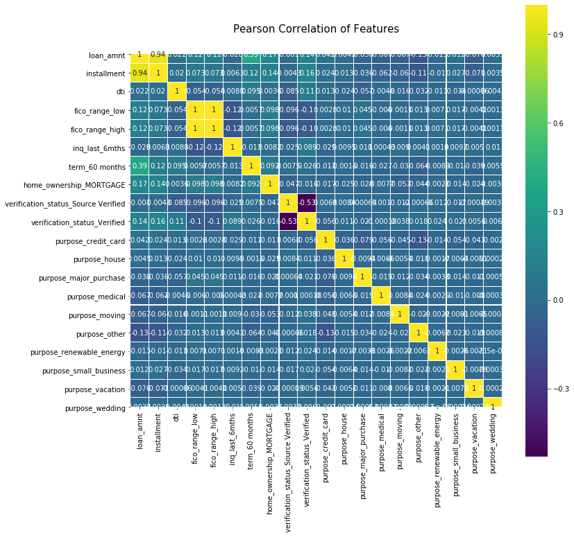

```python
colormap = plt.cm.viridis
plt.figure(figsize=(12,12))
plt.title('Pearson Correlation of Features', y=1.05, size=15)
sns.heatmap(loan[x_chosed].corr(),linewidths=0.1,vmax=1.0, square=True, cmap=colormap, linecolor='white', annot=True)
```

```python
drop_col = ['installment','fico_range_high','term_60 months','verification_status_Verified']
x_new = x_chosed.drop(drop_col)
x_new
```

```
Index(['loan_amnt', 'dti', 'fico_range_low', 'inq_last_6mths',
       'home_ownership_MORTGAGE', 'verification_status_Source Verified',
       'purpose_credit_card', 'purpose_house', 'purpose_major_purchase',
       'purpose_medical', 'purpose_moving', 'purpose_other',
       'purpose_renewable_energy', 'purpose_small_business',
       'purpose_vacation', 'purpose_wedding'],
      dtype='object')
```

### 3.3 Split the Data

```python
# Partition the data
X = loan[x_new]
y = loan["Default"]

from sklearn.model_selection import train_test_split

train_X, test_X, train_y, test_y = train_test_split(X,y,train_size=0.8, random_state = 1)
print ('Train Features: ',train_X.shape ,
      'Test Features: ',test_X.shape)
print ('Train Labels: ',train_y.shape ,
      'Test Labels: ',test_y.shape)
```

```
Train Features:  (60104, 16) Test Features:  (15027, 16)
Train Labels:  (60104,) Test Labels:  (15027,)
```

### 3.4 Balance the Data

Obviously, our dataset is not very balanced since most people would pay their loan. My solution is to use `SMOTE()` function to balance the training dataset.

```python
# SMOTE
n_sample = train_y.shape[0]
n_pos_sample = train_y[train_y == 0].shape[0]
n_neg_sample = train_y[train_y == 1].shape[0]
print('Observations: {}; Positives: {:.2%}; Negatives: {:.2%}'.format(n_sample,
                                                   n_pos_sample / n_sample,
                                                   n_neg_sample / n_sample))
print('Features: ', train_X.shape[1])
```

```
Observations: 60104; Positives: 92.58%; Negatives: 7.42%
Features:  16
```

```python
from imblearn.over_sampling import SMOTE

sm = SMOTE(random_state=1)
train_X, train_y = sm.fit_sample(train_X, train_y)
print('After SMOTE: ')
n_sample = train_y.shape[0]
n_pos_sample = train_y[train_y == 0].shape[0]
n_neg_sample = train_y[train_y == 1].shape[0]
print('Observations: {}; Positives: {:.2%}; Negatives: {:.2%}'.format(n_sample,
                                                   n_pos_sample / n_sample,
                                                   n_neg_sample / n_sample))
```

```
After SMOTE:
Observations: 111284; Positives: 50.00%; Negatives: 50.00%
```

## 4. Modeling

### 4.1 Logistic Regression

```python
from sklearn.linear_model import LogisticRegression
model = LogisticRegression(solver='liblinear')
model.fit(train_X,train_y)
```

```
LogisticRegression(C=1.0, class_weight=None, dual=False, fit_intercept=True,
                   intercept_scaling=1, l1_ratio=None, max_iter=100,
                   multi_class='auto', n_jobs=None, penalty='l2',
                   random_state=None, solver='liblinear', tol=0.0001, verbose=0,
                   warm_start=False)
```

```python
import sklearn.metrics as sklmetrics
predict_y=model.predict(test_X)
sklmetrics.accuracy_score(test_y, predict_y)
```

```
0.5764290942969322
```

```python
# Confusion Matrix
conf_mat = sklmetrics.confusion_matrix(test_y, predict_y, labels =[0,1])
conf_mat
```

```
array([[7938, 5930],
       [ 435,  724]], dtype=int64)
```

```python
from sklearn.metrics import roc_auc_score
roc_auc = roc_auc_score(test_y, predict_y)
print("Area under the ROC curve : %f" % roc_auc)
```

```
Area under the ROC curve : 0.598537
```

```python
def plot_feature_importance_coeff(model, Xnames, cls_nm = None):

    imp_features = pd.DataFrame(np.column_stack((Xnames, model.coef_.ravel())), columns = ['feature', 'importance'])
    imp_features[['importance']] = imp_features[['importance']].astype(float)
    imp_features[['abs_importance']] = imp_features[['importance']].abs()
    # Sort the features based on absolute value of importance
    imp_features = imp_features.sort_values(by = ['abs_importance'], ascending = [1])

    # Plot the feature importances of the forest
    plt.figure()
    plt.title(cls_nm + " - Feature Importance")
    plt.barh(range(imp_features.shape[0]), imp_features['importance'],
            color="b", align="center")
    plt.yticks(range(imp_features.shape[0]), imp_features['feature'], )
    plt.ylim([-1, imp_features.shape[0]])
    plt.xlabel('Importance')
    plt.ylabel('Feature')
    plt.tight_layout()
    plt.savefig(cls_nm + "_feature_imp.png", bbox_inches='tight')
    plt.show()
```

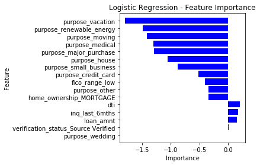

```python
plot_feature_importance_coeff(model, X.columns, cls_nm="Logistic Regression")
```

We found that the **purpose of the specfic loan** is really important for its default probability. Also, **fico score in application** would have a negative effect on the default probability. We should consider these features more carefully when processing an loan application.

### 4.2 Grid Search CV

```python
from sklearn.model_selection import GridSearchCV

param_grid = {'C': 10.**np.arange(-5, 5),
                            'penalty': [ 'l1', 'l2']}

grid_search = GridSearchCV(LogisticRegression(solver='liblinear'),  param_grid, cv=10)
grid_search.fit(train_X, train_y)
```

```
GridSearchCV(cv=10, error_score=nan,
             estimator=LogisticRegression(C=1.0, class_weight=None, dual=False,
                                          fit_intercept=True,
                                          intercept_scaling=1, l1_ratio=None,
                                          max_iter=100, multi_class='auto',
                                          n_jobs=None, penalty='l2',
                                          random_state=None, solver='liblinear',
                                          tol=0.0001, verbose=0,
                                          warm_start=False),
             iid='deprecated', n_jobs=None,
             param_grid={'C': array([1.e-05, 1.e-04, 1.e-03, 1.e-02, 1.e-01, 1.e+00, 1.e+01, 1.e+02,
       1.e+03, 1.e+04]),
                         'penalty': ['l1', 'l2']},
             pre_dispatch='2*n_jobs', refit=True, return_train_score=False,
             scoring=None, verbose=0)
```

```python
print("Best parameters: {}".format(grid_search.best_params_))
print("Best cross-validation score: {:.5f}".format(grid_search.best_score_))
```

```
Best parameters: {'C': 10.0, 'penalty': 'l2'}
Best cross-validation score: 0.61060
```

```python
predict_y=grid_search.predict(test_X)
sklmetrics.accuracy_score(test_y, predict_y)
```

```
0.5762960005323751
```

```python
# Confusion Matrix
conf_mat = sklmetrics.confusion_matrix(test_y, predict_y, labels =[0,1])
conf_mat
```

```
array([[7935, 5933],
       [ 434,  725]], dtype=int64)
```

### 4.3 K-fold Cross Validation

We used the optimal hyperparameter(C=10.0,penalty='l2') generated in the grid search above.

```python
from sklearn.model_selection import cross_val_predict, KFold, cross_val_score
lr = LogisticRegression(C=10.0,penalty='l2',solver='liblinear')
kf = KFold(n_splits=10, shuffle=True)
cross_val_score(lr,train_X, train_y,cv=kf,scoring='accuracy').mean()
```

```
0.610590864865008
```

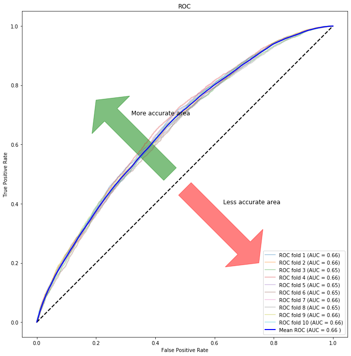

```python
fig1 = plt.figure(figsize=[12,12])
ax1 = fig1.add_subplot(111,aspect = 'equal')
ax1.add_patch(
    patches.Arrow(0.45,0.5,-0.25,0.25,width=0.3,color='green',alpha = 0.5)
    )
ax1.add_patch(
    patches.Arrow(0.5,0.45,0.25,-0.25,width=0.3,color='red',alpha = 0.5)
    )

tprs = []
aucs = []
mean_fpr = np.linspace(0,1,100)
i = 1
for train,test in kf.split(train_X, train_y):
    prediction = lr.fit(train_X.iloc[train],train_y.iloc[train]).predict_proba(train_X.iloc[test])
    fpr, tpr, t = roc_curve(train_y[test], prediction[:, 1])
    tprs.append(interp(mean_fpr, fpr, tpr))
    roc_auc = auc(fpr, tpr)
    aucs.append(roc_auc)
    plt.plot(fpr, tpr, lw=2, alpha=0.3, label='ROC fold %d (AUC = %0.2f)' % (i, roc_auc))
    i= i+1

plt.plot([0,1],[0,1],linestyle = '--',lw = 2,color = 'black')
mean_tpr = np.mean(tprs, axis=0)
mean_auc = auc(mean_fpr, mean_tpr)
plt.plot(mean_fpr, mean_tpr, color='blue',
         label=r'Mean ROC (AUC = %0.2f )' % (mean_auc),lw=2, alpha=1)

plt.xlabel('False Positive Rate')
plt.ylabel('True Positive Rate')
plt.title('ROC')
plt.legend(loc="lower right")
plt.text(0.32,0.7,'More accurate area',fontsize = 12)
plt.text(0.63,0.4,'Less accurate area',fontsize = 12)
plt.show()
```

Besides, a penalty can be added on false negatives since it would be more serious to classify a person would have default as not default than the opposite. It would further improve our accuracy.

## Last Thoughts

**Are there any ways to derive additional variables that would improve the model prediction accuracy?**

- dti_range: Since the orignial dti variable is a continuous feature that needs to be scaled before putting into the model, we can categorize it into several groups / bins. For example, if dti > 10 and dti <= 20, this observation belongs to the dti_range_1020 group.
- annual_inc_range: The same as dti_range
- loan_pay_times: When making decisions, one of our assumption is that all the Defaults are created equal. People who becomes default in their first payment should not be treated as the same as the people who becomes default in their very last payment. With that being said, a label that can categorize different default behaviour is needed.